# RDA project

JBNU statistics

2021 12 14

## 목적 : 단동 비닐하우스 환기율 및 온습도에 대한 예측모형 구축 및 평가 (반응변수 : 환기율)

## 사용모형 : Multiple Linear Regression Model v.s Artificial Neural Network Model (ANN)

## 0. 분석방향

- 환기율을 반응변수로, 외부기온, 외부풍속, 외부일사량, 환기창면적을 독립변수로 하는 선형회귀모형 적합.
- 작물유무에 따라 실험이 수행되었으므로 두 경우에 각각 다른 모형을 적합해보고, 두 데이터세트를 합쳐서 작물유무를 추가 독립변수로 가지는 모형을 또한 적합하여 본다.
- 향후 실험조건 추가에 따라 작물의 크기를 독립변수로 하는 모형 개발이 가능할 것으로 판단된다.
- 환기율은 외부기온, 외부풍속, 환기창면적 등에 의해 계산되는 값이다. 하지만 그 산식이 비선형적이고 복잡하다. 따라서, 본 모형은 외부일사량과 같은 또다른 요인을 고려하여, 물리적 산식에 대한 선형근사식을 찾는 것으로 이해할 수도 있겠다.
- 고려하는 독립변수들은 모두 어느 정도의 중요도를 가진다고 판단된다. 따라서, 영향력이 큰 변수들을 골라내아 단순화된 모형을 찾는 것이 본 분석의 일차적인 목적은 아닐 수 있다.
- 후술하겠지만, 독립변수들간의 교호작용(혹은 상호작용: interaction effect)의 존재가 어느 정도 확인된다. 하지만 교호작용의 포함은 모형의 해석을 난해하게 만들 수 있다.
- 위 요소들을 종합하여, (1) 가능한 모든 효과를 포함한 모형 (2) 예측성능 혹은 변수선택측도 등의 차원에서 가장 우수한 모형 (3) 모든 독립변수들의 주효과를 포함하되 교호작용은 최소한으로 포함한 모형, 크게 3개의 차원에서 모형을 살펴보는 것을 기본 방향으로 한다. 그 예측성능 및 설명력 등을 비교하여 보겠다.

## 1. Loading data

- 작물있음 데이터에서 외부CO2의 값이 결측치인 경우는 제외하였음.

```r
# setwd("D:/OneDrive - 전북대학교/전북대학교/농림과학원용역/2021") # working directory 설정
plantyes <- read.csv("C:/Users/stat/Desktop/작물있음.csv",sep=",",header=T)  # 위 directory에 있는 data 파일 로딩
plantyes <- plantyes[is.na(plantyes$외부CO2)==FALSE,] # 결측치 제외
head(plantyes,10)
```

```
##    외부기온 내부기온 내외부기온차 외부상대습도 내부상대습도 내외부상대습도차
## 1      22.9     31.1          8.3         78.7         55.0             23.7
## 2      22.8     29.7          6.9         77.1         58.7             18.4
## 3      23.3     29.7          6.4         75.5         58.4             17.1
## 4      23.6     29.8          6.2         72.9         57.8             15.1
## 5      24.0     30.0          6.0         71.2         56.4             14.8
## 6      25.1     33.3          8.1         66.6         49.6             17.0
## 7      25.9     35.6          9.7         66.0         43.6             22.4
## 8      25.0     34.0          8.9         68.0         44.9             23.1
## 9      25.9     33.7          7.8         65.6         46.4             19.2
## 10     26.8     35.9          9.1         61.8         44.1             17.7
##    외부CO2 내부CO2 내외부CO2차 외부풍속 외부일사량 환기율 환기창면적 작물유무
## 1    469.5   462.0         7.5    1.398      372.7    5.4       0.15      yes
## 2    464.5   459.7         4.8    1.326      309.9    5.0       0.15      yes
## 3    457.5   451.3         6.2    0.835      291.9    4.0       0.15      yes
```

[output cut: 18 more lines]

```r
plantyes$작물유무 <- as.factor(plantyes$작물유무)     # factor 변수로 변환
plantno <- read.csv("C:/Users/stat/Desktop/작물없음.csv",sep=",",header=T)
head(plantno,10)
```

```
##    외부기온 내부기온 내외부기온차 외부상대습도 내부상대습도 내외부상대습도차
## 1      16.8     27.1         10.3         45.1         39.6              5.5
## 2      17.2     28.3         11.1         42.5         37.6              4.9
## 3      17.6     29.1         11.5         42.9         33.2              9.7
## 4      18.0     30.3         12.4         41.2         32.4              8.8
## 5      17.9     30.6         12.7         37.2         28.8              8.4
## 6      18.0     31.3         13.3         37.4         27.1             10.3
## 7      18.0     31.7         13.7         35.8         25.3             10.5
## 8      18.0     32.0         14.0         38.6         24.4             14.2
## 9      18.3     32.7         14.5         37.0         23.5             13.5
## 10     18.3     32.6         14.3         36.1         22.6             13.5
##    외부CO2 내부CO2 내외부CO2차 외부풍속 외부일사량 환기율 환기창면적 작물유무
## 1    543.5   608.0        64.5    1.576      409.4  0.704       0.04       no
## 2    543.0   580.0        37.0    1.707      442.7  0.756       0.04       no
## 3    522.5   585.5        63.0    1.342      476.5  0.634       0.04       no
```

[output cut: 18 more lines]

```r
plantno$작물유무 <- as.factor(plantno$작물유무)
plant <- rbind(plantno,plantyes)     # 작물유무 데이터 병합
```

## Multiple Linear Regression Model

## 2. 작물유무에 따라 데이터를 나누어서 분석 실시

### 2.1 작물이 없을 때

#### Multiple Linear Regression Model

- 먼저 변수들 간의 상관관계를 파악하기 위해 상관분석을 실시한다.

```r
ex1 <- plantno[,c(12,1,10,11,13,14,15)]   # 분석대상 변수 선택
head(ex1)
```

```
##   환기율 외부기온 외부풍속 외부일사량 환기창면적 작물유무 작물유무수치
## 1  0.704     16.8    1.576      409.4       0.04       no            0
## 2  0.756     17.2    1.707      442.7       0.04       no            0
## 3  0.634     17.6    1.342      476.5       0.04       no            0
## 4  0.798     18.0    1.802      505.7       0.04       no            0
## 5  1.084     17.9    2.583      536.0       0.04       no            0
## 6  1.493     18.0    3.660      564.9       0.04       no            0
```

```r
ex2 <- ex1[,1:5]
```

```r
cor( ex2)   # 상관계수 출력
```

```
##               환기율      외부기온     외부풍속    외부일사량    환기창면적
## 환기율     1.0000000  1.668245e-01 5.063954e-01  6.080400e-02  8.309530e-01
## 외부기온   0.1668245  1.000000e+00 3.063871e-01  3.274643e-01 -9.044468e-20
## 외부풍속   0.5063954  3.063871e-01 1.000000e+00  4.772916e-02  3.715441e-20
## 외부일사량 0.0608040  3.274643e-01 4.772916e-02  1.000000e+00 -5.089237e-20
## 환기창면적 0.8309530 -9.044468e-20 3.715441e-20 -5.089237e-20  1.000000e+00
```

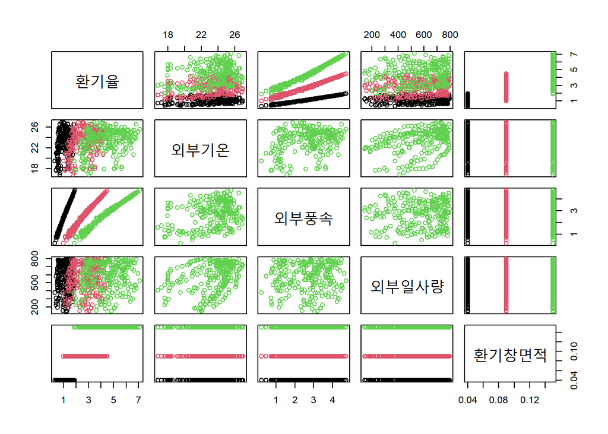

```r
pairs(ex2[1:nrow(plantno),],col=factor(ex2$환기창면적))  # 산점도행렬 출력, 환기창면적에 따라 색깔 표시
```

- 산점도를 통해 알 수 있는 사실은 환기창면적과 외부풍속과의 상호작용(interaction)이 명백하게 존재할 것이라는 것이다. 그 상호작용을 고려한다면 선형모형만으로도 상당히 높은 설명력과 정확한 예측력이 나타날 것으로 생각된다. 외부기온과 외부일사량에 대해서는 환기창면적과의 상호작용은 없거나 강하지 않을 것으로 판단되어 상황에 따라 모형에 포함시키거나 뺄 수 있을 것이다.

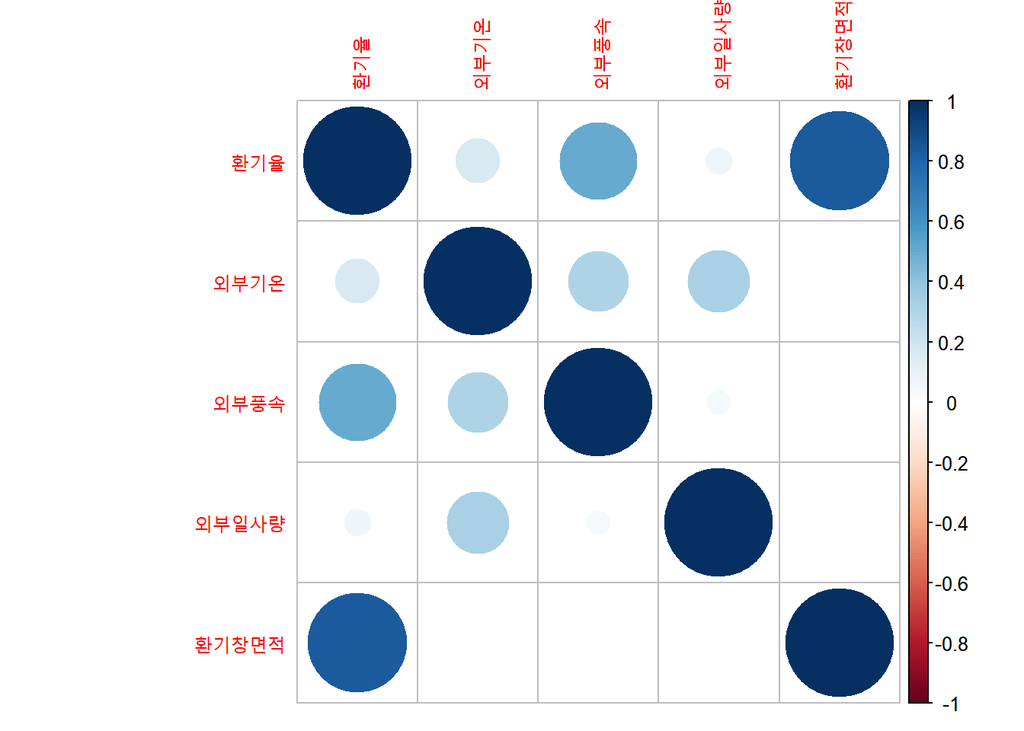

```r
library(corrplot)
corrplot(cor(ex2))   # 상관행렬 시각화
```

- 그리고 각 변수에 대한 기초통계량은 다음과 같이 계산된다.

```r
library(psych)
describe(ex1[,c(-6,-7)])   # 요약통계량 출력
```

```
##            vars   n   mean     sd median trimmed    mad    min    max  range
## 환기율        1 735   2.81   1.64   2.64    2.68   1.86   0.32   7.09   6.78
## 외부기온      2 735  23.39   2.30  24.00   23.66   1.93  16.80  27.00  10.20
## 외부풍속      3 735   2.71   1.08   2.87    2.73   1.29   0.21   4.74   4.54
## 외부일사량    4 735 568.60 171.31 601.10  584.32 191.40 143.00 795.20 652.20
## 환기창면적    5 735   0.09   0.04   0.09    0.09   0.07   0.04   0.15   0.11
##             skew kurtosis   se
## 환기율      0.55    -0.67 0.06
## 외부기온   -0.98     0.30 0.08
## 외부풍속   -0.26    -0.99 0.04
## 외부일사량 -0.63    -0.61 6.32
## 환기창면적  0.11    -1.50 0.00
```

- 환기율을 반응변수로 하여 각 변수의 주효과와, 환기창면적과의 교호작용을 고려한 다중선형회귀모형을 적합하면 다음과 같다.

```r
# 다중선형회귀 모형 적합
m_no <- lm(환기율~외부기온+외부풍속+외부일사량+환기창면적+환기창면적*외부기온+환기창면적*외부풍속+환기창면적*외부일사량,data=plantno)
summary(m_no)   # 결과요약
```

```
##
## Call:
## lm(formula = 환기율 ~ 외부기온 + 외부풍속 + 외부일사량 + 환기창면적 +
##     환기창면적 * 외부기온 + 환기창면적 * 외부풍속 + 환기창면적 *
##     외부일사량, data = plantno)
##
## Residuals:
##      Min       1Q   Median       3Q      Max
## -0.24594 -0.06591 -0.02989  0.06276  0.42450
##
## Coefficients:
##                         Estimate Std. Error t value Pr(>|t|)
## (Intercept)           -3.293e-01  9.129e-02  -3.607  0.00033 ***
## 외부기온               5.934e-03  4.314e-03   1.376  0.16933
## 외부풍속               8.061e-02  8.710e-03   9.255  < 2e-16 ***
## 외부일사량            -7.198e-05  5.509e-05  -1.307  0.19173
## 환기창면적             9.154e+00  8.812e-01  10.388  < 2e-16 ***
## 외부기온:환기창면적   -6.184e-02  4.164e-02  -1.485  0.13794
## 외부풍속:환기창면적    7.370e+00  8.408e-02  87.661  < 2e-16 ***
## 외부일사량:환기창면적  4.525e-03  5.317e-04   8.511  < 2e-16 ***
## ---
## Signif. codes:  0 '***' 0.001 '**' 0.01 '*' 0.05 '.' 0.1 ' ' 1
##
## Residual standard error: 0.1047 on 727 degrees of freedom
## Multiple R-squared:  0.996,  Adjusted R-squared:  0.9959
## F-statistic: 2.557e+04 on 7 and 727 DF,  p-value: < 2.2e-16
```

- 모형적합 결과 외부기온, 외부일사량은 유의수준 0.05에서 유의미하지 않다. 외부풍속과 환기창면적과의 교호작용은 예상한대로 유의미하였고, 외부일사량과 환기창면적과의 교호작용도 유의미한 것으로 나타나기는 하였다. 조정된 결정계수의 값이 $R^2_{adj}=0.9959$이므로 이 모형은 데이터의 변동을 거의 완벽하게 설명하고 있는 것으로 보인다.

#### Best subset selection

- 여러 측도들을 이용하여 모형에 포함될 변수를 적절히 선택해 보도록 하겠다.
- 고려하는 가장 큰 모형 (full model)은 각 독립변수의 주효과와 환기창면적과 다른 독립변수들과의 교호작용을 포함한 모형이다.
- 이는, 환기창면적에 따라서 다른 독립변수들이 환기율에 미치는 영향이 달라질 수 있을 것이라는 생각으로부터 고려된 것이다. 다른 변수들에 의한 교호작용은 산점도 상에서 뚜렷하게 확인되지 않는 것으로 보인다.
- 여러 모형선택의 측도에 따라 몇개의 효과 (그리고 어떤 효과들) 를 포함한 모형이 더 나을지를 1차적으로 판단하기 위한 절차이다.
- 아래 절차에 의해 설명변수의 개수가 $k$개로 고정되어 있을 때 어떤 설명변수 조합이 가장 좋은지를 찾게 된다. $k=1,2,\ldots$로 변화시키면서 변수선택측도들을 계산한다.
- 다양한 변수선택측도(Cp, BIC, adjusted-R2등)에 따라 어느 정도 복잡도(설명변수의 개수)를 가지는 모형이 좋을지, 그 때 포함되어야 하는 효과(혹은 변수)는 무엇인지에 대한 정보를 얻고자 하는 것이다.

```r
library(leaps)   # 필요한 패키지 로딩
# 아래 표현된 모형을 기본으로 하여 최대 7개의 설명변수를 포함하는 모형들에 대하여 변수선택측도 계산
ms0 <- regsubsets(환기율~외부기온+외부풍속+외부일사량+환기창면적+환기창면적*외부기온+환기창면적*외부풍속+환기창면적*외부일사량,data=plantno,
                     nvmax=7)
ms0.summary <- summary(ms0)  # 결과요약
ms0.summary
```

```
## Subset selection object
## Call: regsubsets.formula(환기율 ~ 외부기온 + 외부풍속 + 외부일사량 +
##     환기창면적 + 환기창면적 * 외부기온 + 환기창면적 * 외부풍속 +
##     환기창면적 * 외부일사량, data = plantno, nvmax = 7)
## 7 Variables  (and intercept)
##                       Forced in Forced out
## 외부기온                  FALSE      FALSE
## 외부풍속                  FALSE      FALSE
## 외부일사량                FALSE      FALSE
## 환기창면적                FALSE      FALSE
## 외부기온:환기창면적       FALSE      FALSE
## 외부풍속:환기창면적       FALSE      FALSE
## 외부일사량:환기창면적     FALSE      FALSE
## 1 subsets of each size up to 7
## Selection Algorithm: exhaustive
##          외부기온 외부풍속 외부일사량 환기창면적 외부기온:환기창면적
## 1  ( 1 ) " "      " "      " "        " "        " "
## 2  ( 1 ) " "      " "      " "        "*"        " "
## 3  ( 1 ) " "      " "      " "        "*"        " "
## 4  ( 1 ) " "      "*"      " "        "*"        " "
## 5  ( 1 ) " "      "*"      "*"        "*"        " "
## 6  ( 1 ) "*"      "*"      " "        "*"        "*"
## 7  ( 1 ) "*"      "*"      "*"        "*"        "*"
##          외부풍속:환기창면적 외부일사량:환기창면적
## 1  ( 1 ) "*"                 " "
## 2  ( 1 ) "*"                 " "
## 3  ( 1 ) "*"                 "*"
## 4  ( 1 ) "*"                 "*"
## 5  ( 1 ) "*"                 "*"
## 6  ( 1 ) "*"                 "*"
## 7  ( 1 ) "*"                 "*"
```

```r
par(mfrow=c(2,2))   # 2*2 그림 지정
# RSS=SSE
plot(ms0.summary$rss,xlab="Number of Variables",ylab="RSS",type="l")   # 설명변수 개수에 따른 RSS 값
# Adj R^2
plot(ms0.summary$adjr2,xlab="Number of Variables",ylab="Adjusted RSq",type="l")  # 설명변수 개수에 따른 수정 결정계수  값
which.max(ms0.summary$adjr2)
```

```
## [1] 7
```

```r
points(which.max(ms0.summary$adjr2)
,ms0.summary$adjr2[which.max(ms0.summary$adjr2)
], col="red",cex=2,pch=20)
# Cp
plot(ms0.summary$cp,xlab="Number of Variables",ylab="Cp",type='l')  # 설명변수 개수에 따른 Cp 통계량 값
which.min(ms0.summary$cp)
```

```
## [1] 4
```

```r
points(which.min(ms0.summary$cp)
,ms0.summary$cp[which.min(ms0.summary$cp)
],col="red",cex=2,pch=20)
# BIC
plot(ms0.summary$bic,xlab="Number of Variables",ylab="BIC",type='l')  # 설명변수 개수에 따른 BIC 값
which.min(ms0.summary$bic)
```

```
## [1] 4
```

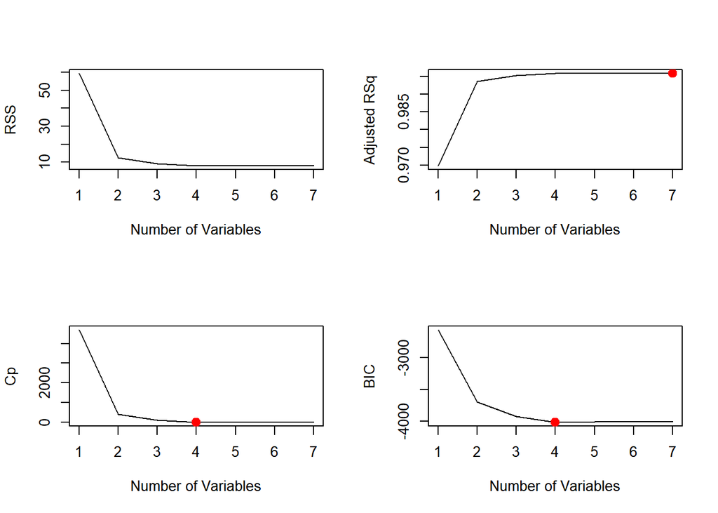

```r
points(which.min(ms0.summary$bic)
,ms0.summary$bic[which.min(ms0.summary$bic)
],col="red",cex=2,pch=20)
```

- Best subset selection의 결과를 보면 설명변수의 개수에 따라 어떤 변수를 넣는것이 바람직한지를 제시하고 있다. 바람직한 설명변수의 개수를 선택하는 데 있어 기준이 되는 통계량 중 $RSS$, $R^2_{adj}$, $C_{p}$, $BIC$를 기준으로 몇개의 설명변수를 선택하는 것이 바람직한지를 살펴보면 위와 같다.
- 위의 결과를 보면 $R^2_{adj}$ 기준으로는 모든 효과를 포함시키는 모형, $C_{p}$, $BIC$ 기준으로는 4개의 설명변수를 선택하는 것이 가장 바람직하다는 결과를 주고 있다. 이 4개의 변수는 외부풍속, 환기창면적, 외부풍속/외부일사량과 환기창면적과의 교호작용이다. 교호작용이 모형에 포함될 때 주효과도 함께 포함하는 것이 보통 자연스러우므로, 결과적으로 외부풍속, 환기창면적, 외부일사량, 외부풍속$\times$환기창면적, 외부일사량$\times$환기창면적 ($\times$는 교호작용을 나타냄.)을 포함한 모형이 비교적 간단하면서 좋은 모형일 수 있겠다.

#### 교차타당검증에 의한 모형 비교

- 지금부터는 train:test=7:3 으로 데이터를 나누어서 몇 개의 후보 모형들의 test RMSE (Root Mean Squared Error)를 계산하여 보겠다. 이 값이 작을수록 예측력이 우수한 모형이라고 볼 수 있다.
- 먼저 데이터를 임의로 train:test=7:3 의 비율로 나눈다. train data는 모형구축 시, test data는 구축된 모형을 평가 시 사용한다.
- 모형에 대한 성능은 test RMSE와 SSE/SST를 바탕으로 실시한다. 정의는 아래같 같다. test RMSE의 경우 test set 에서의 예측오차들의 평균제곱합에 제곱근을 씌운 것이다. SSE/SST의 경우 test error가 반응변수상에 나타나는 총변동 대비 얼마나 되는지를 나타내는 값이다. 두 가지 기준 모두 그 값이 작을수록 모형의 예측력이 우수하다고 판단하면 되는데, SSE/SST의 경우 상대적인 비율로 예측성능을 평가하는 것으로 이해할 있다.
- 여기서 SSE, SST는 평가자료에서 계산되는 값이다.
- $RMSE=\sqrt{{\frac {1}{n} \sum_{i=1}^{n} (y_{i}-\hat{y_{i}})^{2}}}$
- $SSE/SST=\frac {\sum_{i=1}^{n} (y_{i}-\hat{y_{i}})^{2}} {\sum_{i=1}^{n} (y_{i}-\bar{y})^{2}}$

```r
set.seed(5790)  # 실험의 재현성을 위한 seed 설정
train.index <- sample(1:nrow(plantno), round(nrow(plantno)*7/10), replace=F)  # 7:3으로 데이터 분할
ex1_train <- plantno[train.index,]  # 훈련자료
ex1_test <- plantno[-train.index,]  # 평가자료
```

```r
# model1 : 모든 주효과와 교호작용을 포함한 모형
m0 <- lm(환기율~외부기온+외부풍속+외부일사량+환기창면적+환기창면적*외부기온+환기창면적*외부풍속+환기창면적*외부일사량,data=ex1_train)  # 훈련자료에 의한 모형적합
y_hat0 <- predict(m0,ex1_test)  # 적합된 모형을 이용하여 평가자료에서 반응변수의 예측값 산출
RMSE0 <- sqrt(mean((ex1_test$환기율-y_hat0)^2))  # RMSE 계산
SSE0 <- sum((ex1_test$환기율-y_hat0)^2)          # SSE 계산
SST0 <- sum((ex1_test$환기율-mean(ex1_test$환기율))^2)  # SST 계산
result0 <- data.frame(ex1_test$환기율, y_hat0, ex1_test$환기율-y_hat0)
colnames(result0) <- c('y','yhat','y-yhat')
RMSE0 # test RMSE
```

```
## [1] 0.1032797
```

```r
SSE0/SST0 # SSE/SST
```

```
## [1] 0.004055294
```

```r
head(result0,12)
```

```
##        y      yhat       y-yhat
## 3  0.634 0.6494739 -0.015473943
## 5  1.084 1.1162994 -0.032299366
## 7  1.308 1.3403304 -0.032330423
## 10 1.480 1.5152976 -0.035297561
## 12 1.383 1.4294568 -0.046456826
## 17 1.606 1.6597735 -0.053773488
## 20 1.597 1.6555908 -0.058590805
## 24 1.435 1.5012428 -0.066242767
## 33 1.531 1.5963514 -0.065351403
## 51 0.522 0.5308053 -0.008805260
## 60 0.542 0.5107401  0.031259947
## 62 0.655 0.6537715  0.001228533
```

```r
# model2 : Adj R^2, Cp, BIC 등의 기준을 바탕으로 선택된 모형 (교호작용이 있는 경우는 주효과 포함)
m0 <- lm(환기율~외부풍속+외부일사량+환기창면적+환기창면적*외부풍속+환기창면적*외부일사량,data=ex1_train)
y_hat0 <- predict(m0,ex1_test)
RMSE1 <- sqrt(mean((ex1_test$환기율-y_hat0)^2))
SSE1 <- sum((ex1_test$환기율-y_hat0)^2)
SST1 <- sum((ex1_test$환기율-mean(ex1_test$환기율))^2)
result1 <- data.frame(ex1_test$환기율, y_hat0, ex1_test$환기율-y_hat0)
colnames(result1) <- c('y','yhat','y-yhat')
RMSE1 # test RMSE
```

```
## [1] 0.1028304
```

```r
SSE1/SST1 # SSE/SST
```

```
## [1] 0.004020087
```

```r
head(result1,12)
```

```
##        y      yhat      y-yhat
## 3  0.634 0.6753406 -0.04134059
## 5  1.084 1.1472959 -0.06329585
## 7  1.308 1.3748186 -0.06681861
## 10 1.480 1.5519454 -0.07194535
## 12 1.383 1.4576387 -0.07463874
## 17 1.606 1.6838196 -0.07781962
## 20 1.597 1.6747232 -0.07772321
## 24 1.435 1.5104693 -0.07546926
## 33 1.531 1.6000200 -0.06902001
## 51 0.522 0.5505393 -0.02853932
## 60 0.542 0.5175298  0.02447020
## 62 0.655 0.6601474 -0.00514744
```

```r
# model3 : 모든 주효과와 가장 중요한 교호작용 1가지를 포함한 모형 (외부풍속과 환기창면적 사이의 교호작용)
m0 <- lm(환기율~외부기온+외부풍속+외부일사량+환기창면적+외부풍속*환기창면적,data=ex1_train)
y_hat0 <- predict(m0,ex1_test)
RMSE2 <- sqrt(mean((ex1_test$환기율-y_hat0)^2))
SSE2 <- sum((ex1_test$환기율-y_hat0)^2)
SST2 <- sum((ex1_test$환기율-mean(ex1_test$환기율))^2)
result2 <- data.frame(ex1_test$환기율, y_hat0, ex1_test$환기율-y_hat0)
colnames(result2) <- c('y','yhat','y-yhat')
RMSE2 # test RMSE
```

```
## [1] 0.110674
```

```r
SSE2/SST2 # SSE/SST
```

```
## [1] 0.004656759
```

```r
head(result2,12)
```

```
##        y      yhat       y-yhat
## 3  0.634 0.6519275 -0.017927542
## 5  1.084 1.1333225 -0.049322474
## 7  1.308 1.3707212 -0.062721166
## 10 1.480 1.5615367 -0.081536697
## 12 1.383 1.4776223 -0.094622260
## 17 1.606 1.7175113 -0.111511270
## 20 1.597 1.7144213 -0.117421272
## 24 1.435 1.5517568 -0.116756834
## 33 1.531 1.6205526 -0.089552645
## 51 0.522 0.5208783  0.001121732
## 60 0.542 0.5373830  0.004616996
## 62 0.655 0.6871773 -0.032177334
```

- 결과적으로 3가지 모형들 중 두 번째 모형이 가장 우수하였다.
- 그러나 전체적으로 모형들의 예측력이 매우 우수한 편이다. 참고로, 세 모형 모두 오차의 비율이 SST 대비 1% 이하이므로 거의 완벽한 예측이 이루어지고 있다. 이런 측면에서 가장 단순한 모형을 선택하는 것도 좋다.
- `:`표시는 교호작용을 의미함.
- model1 : 모든 주효과와 교호작용을 포함한 모형
  - 반응변수 : 환기율
  - 설명변수 : 외부기온, 외부풍속, 외부일사량, 환기창면적, 외부기온:환기창면적, 외부풍속:환기창면적, 외부일사량:환기창면적
  - RMSE=0.1033, SSE/SST=0.0041
- model2 : Adj R^2, Cp, BIC 등의 기준을 바탕으로 선택된 모형 (교호작용이 있는 경우는 주효과 포함)
  - 반응변수 : 환기율
  - 설명변수 : 외부풍속, 외부일사량, 환기창면적, 외부풍속:환기창면적, 외부일사량:환기창면적
  - RMSE=0.1028, SSE/SST=0.0040
- model3 : 모든 주효과와 가장 중요한 교호작용 1가지를 포함한 모형 (외부풍속과 환기창면적 사이의 교호작용)
  - 반응변수 : 환기율
  - 설명변수 : 외부기온, 외부풍속, 외부일사량, 환기창면적, 외부풍속:환기창면적
  - RMSE=0.1107, SSE/SST=0.0047

#### 아래는 세 모형에 대한 데이터 전체 적합결과이다.

#### 1. model1

```r
summary(lm(환기율~외부기온+외부풍속+외부일사량+환기창면적+환기창면적*외부기온+환기창면적*외부풍속+환기창면적*외부일사량,data=plantno))
```

```
##
## Call:
## lm(formula = 환기율 ~ 외부기온 + 외부풍속 + 외부일사량 + 환기창면적 +
##     환기창면적 * 외부기온 + 환기창면적 * 외부풍속 + 환기창면적 *
##     외부일사량, data = plantno)
##
## Residuals:
##      Min       1Q   Median       3Q      Max
## -0.24594 -0.06591 -0.02989  0.06276  0.42450
##
## Coefficients:
##                         Estimate Std. Error t value Pr(>|t|)
## (Intercept)           -3.293e-01  9.129e-02  -3.607  0.00033 ***
## 외부기온               5.934e-03  4.314e-03   1.376  0.16933
## 외부풍속               8.061e-02  8.710e-03   9.255  < 2e-16 ***
## 외부일사량            -7.198e-05  5.509e-05  -1.307  0.19173
## 환기창면적             9.154e+00  8.812e-01  10.388  < 2e-16 ***
## 외부기온:환기창면적   -6.184e-02  4.164e-02  -1.485  0.13794
## 외부풍속:환기창면적    7.370e+00  8.408e-02  87.661  < 2e-16 ***
## 외부일사량:환기창면적  4.525e-03  5.317e-04   8.511  < 2e-16 ***
## ---
## Signif. codes:  0 '***' 0.001 '**' 0.01 '*' 0.05 '.' 0.1 ' ' 1
##
## Residual standard error: 0.1047 on 727 degrees of freedom
## Multiple R-squared:  0.996,  Adjusted R-squared:  0.9959
## F-statistic: 2.557e+04 on 7 and 727 DF,  p-value: < 2.2e-16
```

#### 2. model2

```r
summary(lm(환기율~외부풍속+외부일사량+환기창면적+환기창면적*외부풍속+환기창면적*외부일사량,data=plantno))
```

```
##
## Call:
## lm(formula = 환기율 ~ 외부풍속 + 외부일사량 + 환기창면적 + 환기창면적 *
##     외부풍속 + 환기창면적 * 외부일사량, data = plantno)
##
## Residuals:
##      Min       1Q   Median       3Q      Max
## -0.24809 -0.06653 -0.02821  0.06283  0.42960
##
## Coefficients:
##                         Estimate Std. Error t value Pr(>|t|)
## (Intercept)           -2.147e-01  3.735e-02  -5.749 1.32e-08 ***
## 외부풍속               8.431e-02  8.288e-03  10.172  < 2e-16 ***
## 외부일사량            -4.705e-05  5.203e-05  -0.904    0.366
## 환기창면적             7.960e+00  3.605e-01  22.080  < 2e-16 ***
## 외부풍속:환기창면적    7.332e+00  8.000e-02  91.648  < 2e-16 ***
## 외부일사량:환기창면적  4.265e-03  5.022e-04   8.494  < 2e-16 ***
## ---
## Signif. codes:  0 '***' 0.001 '**' 0.01 '*' 0.05 '.' 0.1 ' ' 1
##
## Residual standard error: 0.1047 on 729 degrees of freedom
## Multiple R-squared:  0.9959, Adjusted R-squared:  0.9959
## F-statistic: 3.578e+04 on 5 and 729 DF,  p-value: < 2.2e-16
```

#### 3. model3

```r
summary(lm(환기율~외부기온+외부풍속+외부일사량+환기창면적+환기창면적*외부풍속,data=plantno))
```

```
##
## Call:
## lm(formula = 환기율 ~ 외부기온 + 외부풍속 + 외부일사량 + 환기창면적 +
##     환기창면적 * 외부풍속, data = plantno)
##
## Residuals:
##      Min       1Q   Median       3Q      Max
## -0.34686 -0.07838 -0.01231  0.06618  0.42941
##
## Coefficients:
##                       Estimate Std. Error t value Pr(>|t|)
## (Intercept)         -4.360e-01  4.738e-02  -9.202   <2e-16 ***
## 외부기온             1.630e-04  1.963e-03   0.083    0.934
## 외부풍속             8.118e-02  8.766e-03   9.261   <2e-16 ***
## 외부일사량           3.504e-04  2.507e-05  13.976   <2e-16 ***
## 환기창면적           1.030e+01  2.441e-01  42.184   <2e-16 ***
## 외부풍속:환기창면적  7.364e+00  8.377e-02  87.912   <2e-16 ***
## ---
## Signif. codes:  0 '***' 0.001 '**' 0.01 '*' 0.05 '.' 0.1 ' ' 1
##
## Residual standard error: 0.1097 on 729 degrees of freedom
## Multiple R-squared:  0.9955, Adjusted R-squared:  0.9955
## F-statistic: 3.255e+04 on 5 and 729 DF,  p-value: < 2.2e-16
```

#### 해석

- 세 모형 모두 높은 설명력을 보인다.
- 외부기온, 외부풍속, 환기창면적은 양의 계수를 가지므로 커질 수록 환기율이 높아지는 경향이 있다. 단, 외부일사량의 경우는 모향에 따라 연관성의 방향이 바뀌기도 하였으나 모형 내에서 영향력이 그리 크지는 않았다.
- 외부풍속과 환기창면적 사이의 교호작용을 중요한 영향력을 가지는 것으로 평가되며, 교호작용 항의 계수가 양수이다. 즉, 환기창 면적이 클 수록 외부풍속의 증가는 환기율의 더 급속한 증가를 가져온다고 해석할 수 있다.

### 2.2 작물이 있을 때

#### Multiple Linear Regression Model

- 먼저 변수들 간의 상관관계를 파악하기 위해 상관분석을 실시한다.

```r
ex1 <- plantyes[,c(12,1,10,11,13)]
head(ex1)
```

```
##   환기율 외부기온 외부풍속 외부일사량 환기창면적
## 1    5.4     22.9    1.398      372.7       0.15
## 2    5.0     22.8    1.326      309.9       0.15
## 3    4.0     23.3    0.835      291.9       0.15
## 4    4.2     23.6    0.943      297.5       0.15
## 5    5.2     24.0    1.481      335.4       0.15
## 6    4.9     25.1    1.132      549.7       0.15
```

```r
cor(ex1)
```

```
##                환기율    외부기온   외부풍속  외부일사량  환기창면적
## 환기율     1.00000000  0.04996941 0.76546935  0.10313855  0.67141924
## 외부기온   0.04996941  1.00000000 0.12445561  0.47323743 -0.08617862
## 외부풍속   0.76546935  0.12445561 1.00000000  0.01247939  0.10718424
## 외부일사량 0.10313855  0.47323743 0.01247939  1.00000000 -0.01979362
## 환기창면적 0.67141924 -0.08617862 0.10718424 -0.01979362  1.00000000
```

- 산점도행렬과 상관계수그림을 그리면 다음과 같다.

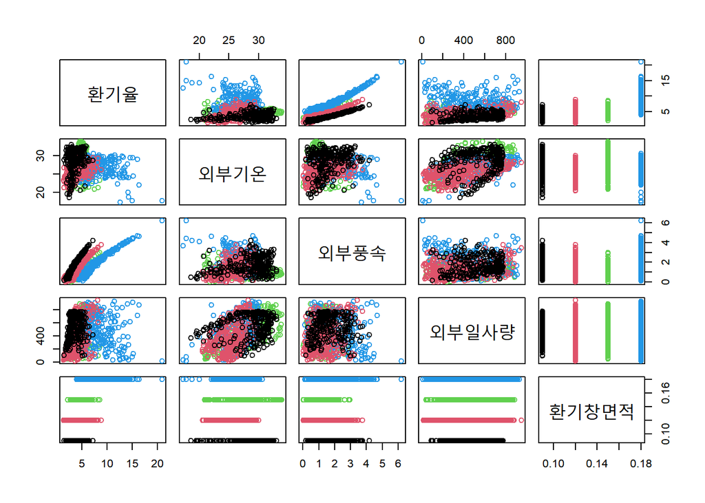

```r
pairs(ex1,col=factor(ex1$환기창면적))
```

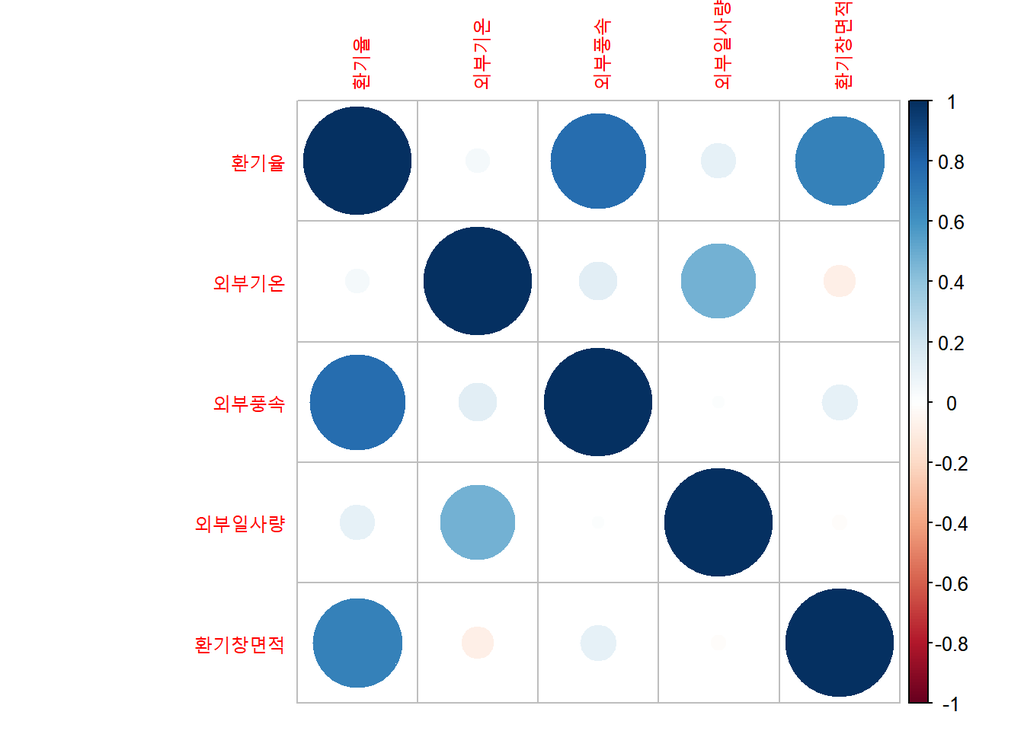

```r
library(corrplot)
corrplot(cor(ex1))
```

- 그리고 각 변수에 대한 기초통계량은 다음과 같이 계산된다.

```r
library(psych)
describe(ex1)
```

```
##            vars    n   mean     sd median trimmed    mad   min    max  range
## 환기율        1 1055   5.15   2.58   4.60    4.77   2.08  1.40  20.90  19.50
## 외부기온      2 1055  26.91   2.99  26.90   26.94   3.26 17.30  33.90  16.60
## 외부풍속      3 1055   1.50   0.92   1.30    1.41   0.83  0.00   6.22   6.21
## 외부일사량    4 1055 459.27 225.19 459.20  460.76 275.02 10.04 950.00 939.96
## 환기창면적    5 1055   0.13   0.03   0.12    0.13   0.04  0.09   0.18   0.09
##             skew kurtosis   se
## 환기율      1.62     3.44 0.08
## 외부기온   -0.12    -0.42 0.09
## 외부풍속    0.97     0.80 0.03
## 외부일사량 -0.02    -1.02 6.93
## 환기창면적  0.12    -1.38 0.00
```

- 환기율을 반응변수로 하여 각 변수의 주효과와 모든 가능한 교호작용을 고려한 다중선형회귀모형을 적합하면 다음과 같다.
- 사전분석 결과 환기창면적과 다른 변수들과의 교호작용 뿐 아니라 다른 효과들도 비교적 유의미하게 관측되었기 때문이다.

```r
m_yes <- lm(환기율~(외부기온+외부풍속+외부일사량+환기창면적)^2,data=plantyes)
summary(m_yes)
```

```
##
## Call:
## lm(formula = 환기율 ~ (외부기온 + 외부풍속 + 외부일사량 + 환기창면적)^2,
##     data = plantyes)
##
## Residuals:
##      Min       1Q   Median       3Q      Max
## -0.80352 -0.18659 -0.03192  0.15923  1.60925
##
## Coefficients:
##                         Estimate Std. Error t value Pr(>|t|)
## (Intercept)           -5.014e+00  4.367e-01 -11.482  < 2e-16 ***
## 외부기온               1.552e-01  1.661e-02   9.341  < 2e-16 ***
## 외부풍속               3.137e-01  1.188e-01   2.640  0.00841 **
## 외부일사량             4.316e-03  4.803e-04   8.986  < 2e-16 ***
## 환기창면적             3.808e+01  2.885e+00  13.199  < 2e-16 ***
## 외부기온:외부풍속     -3.495e-03  3.899e-03  -0.896  0.37038
## 외부기온:외부일사량   -1.188e-04  1.581e-05  -7.512 1.24e-13 ***
## 외부기온:환기창면적   -8.714e-01  1.106e-01  -7.882 8.08e-15 ***
## 외부풍속:외부일사량   -6.916e-04  5.058e-05 -13.672  < 2e-16 ***
## 외부풍속:환기창면적    1.422e+01  3.188e-01  44.617  < 2e-16 ***
## 외부일사량:환기창면적  1.252e-02  1.488e-03   8.414  < 2e-16 ***
## ---
## Signif. codes:  0 '***' 0.001 '**' 0.01 '*' 0.05 '.' 0.1 ' ' 1
##
## Residual standard error: 0.3051 on 1044 degrees of freedom
## Multiple R-squared:  0.9861, Adjusted R-squared:  0.986
## F-statistic:  7408 on 10 and 1044 DF,  p-value: < 2.2e-16
```

- 모형적합 결과 외부기온과 외부풍속 사이의 교호작용이 유의수준 0.05에서 유의미하지 않았다. 조정된 결정계수의 값이 $R^2_{adj}=0.9860$이므로 작물이 없을 때와 비슷한 수준이다.
- 그리고 여러 교호작용들 중 t 통계량의 절대값이 가장 큰 외부풍속과 환기창면적 사이의 교호작용을 1차적으로 고려해 볼 수 있다. 외부풍속과 외부일사량 사이의 교호작용 또한 유의미해 보인다.
- 전체적으로 환기창면적과의 교호작용 뿐 아니라 다양한 교호작용들이 유의미하게 나타난다.

#### Best subset selection

- 여러 측도들을 이용하여 모형에 포함될 변수를 적절히 선택해 보도록 하겠다.
- 전반적인 방향은 작물이 없을 때와 같다.

```r
library(leaps)
ms0 <- regsubsets(환기율~외부기온+외부풍속+외부일사량+환기창면적+환기창면적*외부기온+환기창면적*외부풍속+환기창면적*외부일사량,data=plantyes,
                     nvmax=7)
ms0.summary <- summary(ms0)
ms0.summary
```

```
## Subset selection object
## Call: regsubsets.formula(환기율 ~ 외부기온 + 외부풍속 + 외부일사량 +
##     환기창면적 + 환기창면적 * 외부기온 + 환기창면적 * 외부풍속 +
##     환기창면적 * 외부일사량, data = plantyes, nvmax = 7)
## 7 Variables  (and intercept)
##                       Forced in Forced out
## 외부기온                  FALSE      FALSE
## 외부풍속                  FALSE      FALSE
## 외부일사량                FALSE      FALSE
## 환기창면적                FALSE      FALSE
## 외부기온:환기창면적       FALSE      FALSE
## 외부풍속:환기창면적       FALSE      FALSE
## 외부일사량:환기창면적     FALSE      FALSE
## 1 subsets of each size up to 7
## Selection Algorithm: exhaustive
##          외부기온 외부풍속 외부일사량 환기창면적 외부기온:환기창면적
## 1  ( 1 ) " "      " "      " "        " "        " "
## 2  ( 1 ) " "      " "      " "        "*"        " "
## 3  ( 1 ) " "      " "      "*"        "*"        " "
## 4  ( 1 ) " "      " "      "*"        "*"        "*"
## 5  ( 1 ) "*"      " "      " "        "*"        "*"
## 6  ( 1 ) "*"      " "      "*"        "*"        "*"
## 7  ( 1 ) "*"      "*"      "*"        "*"        "*"
##          외부풍속:환기창면적 외부일사량:환기창면적
## 1  ( 1 ) "*"                 " "
## 2  ( 1 ) "*"                 " "
## 3  ( 1 ) "*"                 " "
## 4  ( 1 ) "*"                 " "
## 5  ( 1 ) "*"                 "*"
## 6  ( 1 ) "*"                 "*"
## 7  ( 1 ) "*"                 "*"
```

```r
par(mfrow=c(2,2))
# RSS=SSE
plot(ms0.summary$rss,xlab="Number of Variables",ylab="RSS",type="l")
# Adj R^2
plot(ms0.summary$adjr2,xlab="Number of Variables",ylab="Adjusted RSq",type="l")
which.max(ms0.summary$adjr2)
```

```
## [1] 7
```

```r
points(which.max(ms0.summary$adjr2)
,ms0.summary$adjr2[which.max(ms0.summary$adjr2)
], col="red",cex=2,pch=20)
# Cp
plot(ms0.summary$cp,xlab="Number of Variables",ylab="Cp",type='l')
which.min(ms0.summary$cp)
```

```
## [1] 7
```

```r
points(which.min(ms0.summary$cp)
,ms0.summary$cp[which.min(ms0.summary$cp)
],col="red",cex=2,pch=20)
# BIC
plot(ms0.summary$bic,xlab="Number of Variables",ylab="BIC",type='l')
which.min(ms0.summary$bic)
```

```
## [1] 6
```

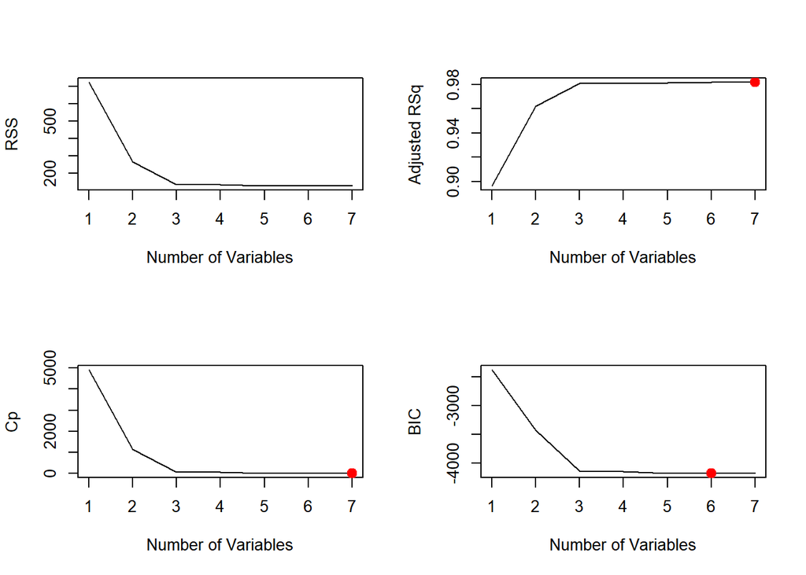

```r
points(which.min(ms0.summary$bic)
,ms0.summary$bic[which.min(ms0.summary$bic)
],col="red",cex=2,pch=20)
```

- Best subset selection의 결과를 보면 설명변수의 개수에 따라 어떤 변수를 넣는것이 바람직한지를 제시하고 있다. 바람직한 설명변수의 개수를 선택하는 데 있어 기준이 되는 통계량 중 $RSS$, $R^2_{adj}$, $C_{p}$, $BIC$를 기준으로 몇개의 설명변수를 선택하는 것이 바람직한지를 살펴보면 위와 같다.
- 모든 변수를 포함시키는 것이 좋다는 결론이 우세하다. BIC 기준으로는 외부풍속 주효과를 제거하는 것이 좋다고 나오는데 외부풍속은 중요한 요소이므로 빼지 않는 것이 좋아 보인다.
- 하지만, 측도들이 변수 3개 이상에서 안정화되는 경향이 있어 모형의 단순화를 위해서는 3개 예측변수만을 포함하는 모형도 나쁘지 않아 보인다. 이는 외부일사량, 환기창면적, 외부풍속과 환기창면적과의 교호작용을 포함하는 모형이다. 외부풍속의 주효과도 추가적으로 고려한다.

#### 교차타당검증에 의한 모형 비교

- 지금부터는 train:test=7:3 으로 데이터를 나누어서 몇 개의 후보 모형들의 test RMSE를 계산하여 보겠다. 이 값이 작을수록 예측력이 우수한 모형이라고 볼 수 있다.
- 먼저 데이터를 임의로 train:test=7:3 의 비율로 나눈다. train data는 모형구축 시, test data는 구축된 모형을 평가 시 사용한다.
- 모형에 대한 성능은 test RMSE와 SSE/SST를 바탕으로 실시하며, 두가지 기준 모두 그 값이 작을수록 모형의 예측력이 우수하다고 판단하면 된다.
- $RMSE=\sqrt{{\frac {1}{n} \sum_{i=1}^{n} (y_{i}-\hat{y_{i}})^{2}}}$
- $SSE/SST=\frac {\sum_{i=1}^{n} (y_{i}-\hat{y_{i}})^{2}} {\sum_{i=1}^{n} (y_{i}-\bar{y})^{2}}$

```r
set.seed(5790)
train.index <- sample(1:nrow(plantyes), round(nrow(plantyes)*7/10), replace=F)
ex1_train <- plantyes[train.index,]
ex1_test <- plantyes[-train.index,]
```

```r
# model1 : 모든 주효과 및 교호작용을 포함한 모형
m0 <- lm(환기율~외부기온+외부풍속+외부일사량+환기창면적+환기창면적*외부기온+환기창면적*외부풍속+환기창면적*외부일사량,data=ex1_train)
y_hat0 <- predict(m0,ex1_test)
RMSE0 <- sqrt(mean((ex1_test$환기율-y_hat0)^2))
SSE0 <- sum((ex1_test$환기율-y_hat0)^2)
SST0 <- sum((ex1_test$환기율-mean(ex1_test$환기율))^2)
result0 <- data.frame(ex1_test$환기율, y_hat0, ex1_test$환기율-y_hat0)
colnames(result0) <- c('y','yhat','y-yhat')
RMSE0 # test RMSE
```

```
## [1] 0.3649183
```

```r
SSE0/SST0 # SSE/SST
```

```
## [1] 0.0216863
```

```r
head(result0,12)
```

```
##      y     yhat      y-yhat
## 3  4.0 4.210719 -0.21071942
## 5  5.2 5.588240 -0.38823973
## 10 4.5 4.541649 -0.04164922
## 12 4.4 3.816247  0.58375307
## 17 4.6 4.485247  0.11475300
## 20 4.1 3.396015  0.70398522
## 23 3.9 3.358263  0.54173747
## 24 5.2 5.281626 -0.08162571
## 33 5.3 5.169016  0.13098414
## 39 5.4 5.345798  0.05420211
## 45 6.0 5.927317  0.07268276
## 54 5.2 5.832707 -0.63270717
```

```r
# model2 : Adj R^2, Cp, BIC 등의 기준을 바탕으로 선택된 모형 (교호작용이 있는 경우는 주효과 포함)
m0 <- lm(환기율~외부풍속+외부일사량+환기창면적+환기창면적*외부풍속,data=ex1_train)
y_hat0 <- predict(m0,ex1_test)
RMSE1 <- sqrt(mean((ex1_test$환기율-y_hat0)^2))
SSE1 <- sum((ex1_test$환기율-y_hat0)^2)
SST1 <- sum((ex1_test$환기율-mean(ex1_test$환기율))^2)
result1 <- data.frame(ex1_test$환기율, y_hat0, ex1_test$환기율-y_hat0)
colnames(result1) <- c('y','yhat','y-yhat')
RMSE1 # test RMSE
```

```
## [1] 0.3762032
```

```r
SSE1/SST1 # SSE/SST
```

```
## [1] 0.02304831
```

```r
head(result1,12)
```

```
##      y     yhat      y-yhat
## 3  4.0 4.138183 -0.13818333
## 5  5.2 5.530338 -0.33033820
## 10 4.5 4.518282 -0.01828181
## 12 4.4 3.790699  0.60930144
## 17 4.6 4.518579  0.08142063
## 20 4.1 3.435502  0.66449825
## 23 3.9 3.441636  0.45836386
## 24 5.2 5.346505 -0.14650505
## 33 5.3 5.285295  0.01470479
## 39 5.4 5.482614 -0.08261388
## 45 6.0 6.075957 -0.07595713
## 54 5.2 5.746243 -0.54624312
```

```r
# model3 : 모든 주효과, 그리고 중요한 1개의 교호작용을 포함한 모형
m0 <- lm(환기율~외부기온+외부풍속+외부일사량+환기창면적+환기창면적*외부풍속,data=ex1_train)
y_hat0 <- predict(m0,ex1_test)
RMSE2 <- sqrt(mean((ex1_test$환기율-y_hat0)^2))
SSE2 <- sum((ex1_test$환기율-y_hat0)^2)
SST2 <- sum((ex1_test$환기율-mean(ex1_test$환기율))^2)
result2 <- data.frame(ex1_test$환기율, y_hat0, ex1_test$환기율-y_hat0)
colnames(result2) <- c('y','yhat','y-yhat')
RMSE2 # test RMSE
```

```
## [1] 0.375678
```

```r
SSE2/SST2 # SSE/SST
```

```
## [1] 0.022984
```

```r
head(result2,12)
```

```
##      y     yhat      y-yhat
## 3  4.0 4.166040 -0.16604038
## 5  5.2 5.555648 -0.35564815
## 10 4.5 4.524739 -0.02473917
## 12 4.4 3.795493  0.60450675
## 17 4.6 4.504664  0.09533581
## 20 4.1 3.415787  0.68421322
## 23 3.9 3.406813  0.49318662
## 24 5.2 5.322057 -0.12205691
## 33 5.3 5.237255  0.06274456
## 39 5.4 5.429891 -0.02989125
## 45 6.0 6.025670 -0.02567016
## 54 5.2 5.786485 -0.58648486
```

#### 1. model1

```r
summary(lm(환기율~외부기온+외부풍속+외부일사량+환기창면적+환기창면적*외부기온+환기창면적*외부풍속+환기창면적*외부일사량,data=plantno) )
```

```
##
## Call:
## lm(formula = 환기율 ~ 외부기온 + 외부풍속 + 외부일사량 + 환기창면적 +
##     환기창면적 * 외부기온 + 환기창면적 * 외부풍속 + 환기창면적 *
##     외부일사량, data = plantno)
##
## Residuals:
##      Min       1Q   Median       3Q      Max
## -0.24594 -0.06591 -0.02989  0.06276  0.42450
##
## Coefficients:
##                         Estimate Std. Error t value Pr(>|t|)
## (Intercept)           -3.293e-01  9.129e-02  -3.607  0.00033 ***
## 외부기온               5.934e-03  4.314e-03   1.376  0.16933
## 외부풍속               8.061e-02  8.710e-03   9.255  < 2e-16 ***
## 외부일사량            -7.198e-05  5.509e-05  -1.307  0.19173
## 환기창면적             9.154e+00  8.812e-01  10.388  < 2e-16 ***
## 외부기온:환기창면적   -6.184e-02  4.164e-02  -1.485  0.13794
## 외부풍속:환기창면적    7.370e+00  8.408e-02  87.661  < 2e-16 ***
## 외부일사량:환기창면적  4.525e-03  5.317e-04   8.511  < 2e-16 ***
## ---
## Signif. codes:  0 '***' 0.001 '**' 0.01 '*' 0.05 '.' 0.1 ' ' 1
##
## Residual standard error: 0.1047 on 727 degrees of freedom
## Multiple R-squared:  0.996,  Adjusted R-squared:  0.9959
## F-statistic: 2.557e+04 on 7 and 727 DF,  p-value: < 2.2e-16
```

#### 2. model2

```r
summary(lm(환기율~외부풍속+외부일사량+환기창면적+환기창면적*외부풍속,data=plantno) )
```

```
##
## Call:
## lm(formula = 환기율 ~ 외부풍속 + 외부일사량 + 환기창면적 + 환기창면적 *
##     외부풍속, data = plantno)
##
## Residuals:
##      Min       1Q   Median       3Q      Max
## -0.34675 -0.07840 -0.01278  0.06621  0.42922
##
## Coefficients:
##                       Estimate Std. Error t value Pr(>|t|)
## (Intercept)         -4.329e-01  2.840e-02  -15.24   <2e-16 ***
## 외부풍속             8.128e-02  8.674e-03    9.37   <2e-16 ***
## 외부일사량           3.510e-04  2.366e-05   14.84   <2e-16 ***
## 환기창면적           1.030e+01  2.439e-01   42.21   <2e-16 ***
## 외부풍속:환기창면적  7.364e+00  8.371e-02   87.97   <2e-16 ***
## ---
## Signif. codes:  0 '***' 0.001 '**' 0.01 '*' 0.05 '.' 0.1 ' ' 1
##
## Residual standard error: 0.1097 on 730 degrees of freedom
## Multiple R-squared:  0.9955, Adjusted R-squared:  0.9955
## F-statistic: 4.074e+04 on 4 and 730 DF,  p-value: < 2.2e-16
```

#### 3. model3

```r
summary(lm(환기율~외부기온+외부풍속+외부일사량+환기창면적+환기창면적*외부풍속,data=plantno) )
```

```
##
## Call:
## lm(formula = 환기율 ~ 외부기온 + 외부풍속 + 외부일사량 + 환기창면적 +
##     환기창면적 * 외부풍속, data = plantno)
##
## Residuals:
##      Min       1Q   Median       3Q      Max
## -0.34686 -0.07838 -0.01231  0.06618  0.42941
##
## Coefficients:
##                       Estimate Std. Error t value Pr(>|t|)
## (Intercept)         -4.360e-01  4.738e-02  -9.202   <2e-16 ***
## 외부기온             1.630e-04  1.963e-03   0.083    0.934
## 외부풍속             8.118e-02  8.766e-03   9.261   <2e-16 ***
## 외부일사량           3.504e-04  2.507e-05  13.976   <2e-16 ***
## 환기창면적           1.030e+01  2.441e-01  42.184   <2e-16 ***
## 외부풍속:환기창면적  7.364e+00  8.377e-02  87.912   <2e-16 ***
## ---
## Signif. codes:  0 '***' 0.001 '**' 0.01 '*' 0.05 '.' 0.1 ' ' 1
##
## Residual standard error: 0.1097 on 729 degrees of freedom
## Multiple R-squared:  0.9955, Adjusted R-squared:  0.9955
## F-statistic: 3.255e+04 on 5 and 729 DF,  p-value: < 2.2e-16
```

### 2.3 작물유무 데이터를 합친 경우

#### Multiple Linear Regression Model

- 상관분석 등의 절차는 앞서 데이터를 나누어 각각 수행하였으므로 생략한다.
- 환기율을 반응변수로 하여 기존 독립변수들에 작물유무를 나타내는 변수를 추가하여 고려한다.
- 작물유무에 따라 데이터세트를 나누어서 선형모형을 적합한 결과로부터, 두 적합모형은 형태가 약간 다르다. 이는 작물유무와 다른 독립변수들과의 교호작용의 존재 가능성을 함축한다.
- 너무 많은 교호작용을 포함하는 것은 모형을 지나치게 복잡하게 만들 수 있다. 앞서서 적합한 여러 모형들을 살펴보면 교호작용들 중 외부풍속과 환기창면적 사이의 효과만 고려한 모형도 test RMSE와 설명력의 관점에서 충분히 우수하고 경쟁력이 있었다.
- 따라서, 외부기온, 외부풍속, 외부일사량, 환기창면적, 외부풍속$\times$환기창면적이 포함된 모형을 기본으로 이들과 작물유무 및 작물유무와의 교호작용을 고려한 모형을 시작점으로 삼도록 하겠다. 단, 세 변수 이상의 교호작용은 단순성을 위해 고려하지 않는다. 아래는 해당모형의 적합결과이다.

```r
m_total <- lm(환기율~외부기온+외부풍속+외부일사량+환기창면적+작물유무+외부기온*작물유무+외부풍속*작물유무+외부일사량*작물유무+환기창면적*작물유무+환기창면적*외부풍속,data=plant)
summary(m_total)
```

```
##
## Call:
## lm(formula = 환기율 ~ 외부기온 + 외부풍속 + 외부일사량 + 환기창면적 +
##     작물유무 + 외부기온 * 작물유무 + 외부풍속 * 작물유무 + 외부일사량 *
##     작물유무 + 환기창면적 * 작물유무 + 환기창면적 * 외부풍속,
##     data = plant)
##
## Residuals:
##     Min      1Q  Median      3Q     Max
## -1.2387 -0.1822 -0.0153  0.1330  3.3386
##
## Coefficients:
##                          Estimate Std. Error t value Pr(>|t|)
## (Intercept)             2.226e-01  1.297e-01   1.716  0.08627 .
## 외부기온                1.630e-04  5.590e-03   0.029  0.97674
## 외부풍속               -1.620e-01  2.084e-02  -7.773 1.29e-14 ***
## 외부일사량              3.504e-04  7.138e-05   4.908 1.00e-06 ***
## 환기창면적              3.241e+00  5.693e-01   5.692 1.47e-08 ***
## 작물유무yes            -1.934e+00  1.586e-01 -12.199  < 2e-16 ***
## 외부기온:작물유무yes   -2.006e-02  6.721e-03  -2.985  0.00288 **
## 외부풍속:작물유무yes    7.009e-01  1.823e-02  38.445  < 2e-16 ***
## 외부일사량:작물유무yes  1.240e-03  8.639e-05  14.357  < 2e-16 ***
## 환기창면적:작물유무yes  2.512e+01  4.300e-01  58.415  < 2e-16 ***
## 외부풍속:환기창면적     9.969e+00  1.877e-01  53.117  < 2e-16 ***
## ---
## Signif. codes:  0 '***' 0.001 '**' 0.01 '*' 0.05 '.' 0.1 ' ' 1
##
## Residual standard error: 0.3125 on 1779 degrees of freedom
## Multiple R-squared:  0.9847, Adjusted R-squared:  0.9846
## F-statistic: 1.144e+04 on 10 and 1779 DF,  p-value: < 2.2e-16
```

- 조정된 결정계수의 값이 $R^2_{adj}=0.9846$이므로 설명력이 매우 높은 수준이다.

#### Best subset selection

- 여러 측도들을 이용하여 모형에 포함될 변수를 적절히 선택해 보도록 하겠다.

```r
library(leaps)
ms0 <- regsubsets(환기율~외부기온+외부풍속+외부일사량+환기창면적+작물유무+외부기온*작물유무+외부풍속*작물유무+외부일사량*작물유무+환기창면적*작물유무+환기창면적*외부풍속,data=plant,nvmax=10)
ms0.summary <- summary(ms0)
ms0.summary
```

```
## Subset selection object
## Call: regsubsets.formula(환기율 ~ 외부기온 + 외부풍속 + 외부일사량 +
##     환기창면적 + 작물유무 + 외부기온 * 작물유무 + 외부풍속 *
##     작물유무 + 외부일사량 * 작물유무 + 환기창면적 * 작물유무 +
##     환기창면적 * 외부풍속, data = plant, nvmax = 10)
## 10 Variables  (and intercept)
##                        Forced in Forced out
## 외부기온                   FALSE      FALSE
## 외부풍속                   FALSE      FALSE
## 외부일사량                 FALSE      FALSE
## 환기창면적                 FALSE      FALSE
## 작물유무yes                FALSE      FALSE
## 외부기온:작물유무yes       FALSE      FALSE
## 외부풍속:작물유무yes       FALSE      FALSE
## 외부일사량:작물유무yes     FALSE      FALSE
## 환기창면적:작물유무yes     FALSE      FALSE
## 외부풍속:환기창면적        FALSE      FALSE
## 1 subsets of each size up to 10
## Selection Algorithm: exhaustive
##           외부기온 외부풍속 외부일사량 환기창면적 작물유무yes
## 1  ( 1 )  " "      " "      " "        "*"        " "
## 2  ( 1 )  " "      " "      " "        " "        " "
## 3  ( 1 )  " "      " "      "*"        " "        " "
## 4  ( 1 )  " "      " "      "*"        " "        " "
## 5  ( 1 )  " "      " "      " "        " "        "*"
## 6  ( 1 )  " "      "*"      " "        " "        "*"
## 7  ( 1 )  " "      "*"      " "        "*"        "*"
## 8  ( 1 )  " "      "*"      " "        "*"        "*"
## 9  ( 1 )  " "      "*"      "*"        "*"        "*"
## 10  ( 1 ) "*"      "*"      "*"        "*"        "*"
##           외부기온:작물유무yes 외부풍속:작물유무yes 외부일사량:작물유무yes
## 1  ( 1 )  " "                  " "                  " "
## 2  ( 1 )  " "                  " "                  " "
## 3  ( 1 )  " "                  " "                  " "
## 4  ( 1 )  " "                  "*"                  " "
## 5  ( 1 )  " "                  "*"                  "*"
## 6  ( 1 )  " "                  "*"                  "*"
## 7  ( 1 )  " "                  "*"                  "*"
## 8  ( 1 )  "*"                  "*"                  "*"
## 9  ( 1 )  "*"                  "*"                  "*"
## 10  ( 1 ) "*"                  "*"                  "*"
##           환기창면적:작물유무yes 외부풍속:환기창면적
## 1  ( 1 )  " "                    " "
## 2  ( 1 )  "*"                    "*"
## 3  ( 1 )  "*"                    "*"
## 4  ( 1 )  "*"                    "*"
## 5  ( 1 )  "*"                    "*"
## 6  ( 1 )  "*"                    "*"
## 7  ( 1 )  "*"                    "*"
## 8  ( 1 )  "*"                    "*"
## 9  ( 1 )  "*"                    "*"
## 10  ( 1 ) "*"                    "*"
```

```r
par(mfrow=c(2,2))
# RSS=SSE
plot(ms0.summary$rss,xlab="Number of Variables",ylab="RSS",type="l")
# Adj R^2
plot(ms0.summary$adjr2,xlab="Number of Variables",ylab="Adjusted RSq",type="l")
which.max(ms0.summary$adjr2)
```

```
## [1] 9
```

```r
points(which.max(ms0.summary$adjr2)
,ms0.summary$adjr2[which.max(ms0.summary$adjr2)
], col="red",cex=2,pch=20)
# Cp
plot(ms0.summary$cp,xlab="Number of Variables",ylab="Cp",type='l')
which.min(ms0.summary$cp)
```

```
## [1] 9
```

```r
points(which.min(ms0.summary$cp)
,ms0.summary$cp[which.min(ms0.summary$cp)
],col="red",cex=2,pch=20)
# BIC
plot(ms0.summary$bic,xlab="Number of Variables",ylab="BIC",type='l')
which.min(ms0.summary$bic)
```

```
## [1] 9
```

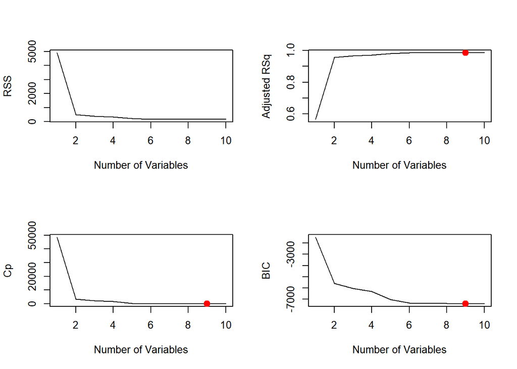

```r
points(which.min(ms0.summary$bic)
,ms0.summary$bic[which.min(ms0.summary$bic)
],col="red",cex=2,pch=20)
```

```r
par(mfrow=c(1,1))
```

- Best subset selection의 결과를 보면 설명변수의 개수에 따라 어떤 변수를 넣는것이 바람직한지를 제시하고 있다. 바람직한 설명변수의 개수를 선택하는 데 있어 기준이 되는 통계량 중 $RSS$, $R^2_{adj}$, $C_{p}$, $BIC$를 기준으로 몇개의 설명변수를 선택하는 것이 바람직한지를 살펴보면 위와 같다.
- 외부기온을 제거하는 모형을 선택하고 있다. 한편, 외부기온과 작물유무와의 교호작용도 제거될 수 있는 효과 중 하나로 보인다.
- 교호작용 효과들도 대부분 모형에서 중요한 것으로 보인다. 하지만 이 효과는 모형의 해석을 매우 복잡하게 만들 수 있으므로 꼭 포함시키는 것이 필요할지 검토가 필요하다.

#### 교차타당검증에 의한 모형 비교

- 지금부터는 train:test=7:3 으로 데이터를 나누어서 몇 개의 후보 모형들의 test RMSE를 계산하여 보겠다. 이 값이 작을수록 예측력이 우수한 모형이라고 볼 수 있다.
- 먼저 데이터를 임의로 train:test=7:3 의 비율로 나눈다. train data는 모형구축 시, test data는 구축된 모형을 평가 시 사용한다.
- 모형에 대한 성능은 test RMSE와 SSE/SST를 바탕으로 실시하며, 두가지 기준 모두 그 값이 작을수록 모형의 예측력이 우수하다고 판단하면 된다.
- $RMSE=\sqrt{{\frac {1}{n} \sum_{i=1}^{n} (y_{i}-\hat{y_{i}})^{2}}}$
- $SSE/SST=\frac {\sum_{i=1}^{n} (y_{i}-\hat{y_{i}})^{2}} {\sum_{i=1}^{n} (y_{i}-\bar{y})^{2}}$

```r
set.seed(5790)
train.index <- sample(1:nrow(plant), round(nrow(plant)*7/10), replace=F)
ex1_train <- plant[train.index,]
ex1_test <- plant[-train.index,]
```

```r
# model1 : 최초로 고려한 모형
m0 <- lm(환기율~외부기온+외부풍속+외부일사량+환기창면적+작물유무+외부기온*작물유무+외부풍속*작물유무+외부일사량*작물유무+환기창면적*작물유무+환기창면적*외부풍속,data=ex1_train)
y_hat0 <- predict(m0,ex1_test)
RMSE0 <- sqrt(mean((ex1_test$환기율-y_hat0)^2))
SSE0 <- sum((ex1_test$환기율-y_hat0)^2)
SST0 <- sum((ex1_test$환기율-mean(ex1_test$환기율))^2)
result0 <- data.frame(ex1_test$환기율, y_hat0, ex1_test$환기율-y_hat0)
colnames(result0) <- c('y','yhat','y-yhat')
RMSE0 # test RMSE
```

```
## [1] 0.2840299
```

```r
SSE0/SST0 # SSE/SST
```

```
## [1] 0.01321861
```

```r
head(result0,12)
```

```
##        y      yhat       y-yhat
## 3  0.634 0.8668984 -0.232898370
## 12 1.383 1.3920132 -0.009013189
## 15 1.761 1.6256311  0.135368915
## 17 1.606 1.5430345  0.062965480
## 23 1.215 1.3119390 -0.096938999
## 24 1.435 1.4421332 -0.007133154
## 37 1.099 1.1816420 -0.082642000
## 39 1.206 1.2308139 -0.024813863
## 43 1.222 1.2025609  0.019439134
## 48 1.080 1.0697472  0.010252791
## 51 0.522 0.7812334 -0.259233358
## 57 0.640 0.8848404 -0.244840360
```

```r
# model2 : 모든 주효과와 작물유무, 외부풍속, 환기창면적과의 교호작용만을 포함한 모형
m0 <- lm(환기율~외부풍속+외부일사량+환기창면적+작물유무+
              외부풍속*작물유무+외부일사량*작물유무+환기창면적*작물유무+환기창면적:외부풍속,data=ex1_train)
y_hat0 <- predict(m0,ex1_test)
RMSE1 <- sqrt(mean((ex1_test$환기율-y_hat0)^2))
SSE1 <- sum((ex1_test$환기율-y_hat0)^2)
SST1 <- sum((ex1_test$환기율-mean(ex1_test$환기율))^2)
result1 <- data.frame(ex1_test$환기율, y_hat0, ex1_test$환기율-y_hat0)
colnames(result1) <- c('y','yhat','y-yhat')
RMSE1 # test RMSE
```

```
## [1] 0.2854564
```

```r
SSE1/SST1 # SSE/SST
```

```
## [1] 0.01335173
```

```r
head(result1,12)
```

```
##        y      yhat       y-yhat
## 3  0.634 0.8704119 -0.236411942
## 12 1.383 1.3847880 -0.001787986
## 15 1.761 1.6133589  0.147641099
## 17 1.606 1.5333989  0.072601131
## 23 1.215 1.3101011 -0.095101144
## 24 1.435 1.4371164 -0.002116443
## 37 1.099 1.1827705 -0.083770490
## 39 1.206 1.2301028 -0.024102757
## 43 1.222 1.2009391  0.021060948
## 48 1.080 1.0702312  0.009768823
## 51 0.522 0.7872840 -0.265283968
## 57 0.640 0.8904624 -0.250462390
```

```r
# model3 : 모든 주효과와 작물유무, 외부풍속, 환기창면적과의 교호작용만을 포함한 모형
m0 <- lm(환기율~외부기온+외부풍속+외부일사량+환기창면적+작물유무+외부풍속*작물유무+환기창면적*작물유무+외부풍속*환기창면적,data=ex1_train)
y_hat0 <- predict(m0,ex1_test)
RMSE2 <- sqrt(mean((ex1_test$환기율-y_hat0)^2))
SSE2 <- sum((ex1_test$환기율-y_hat0)^2)
SST2 <- sum((ex1_test$환기율-mean(ex1_test$환기율))^2)
result2 <- data.frame(ex1_test$환기율, y_hat0, ex1_test$환기율-y_hat0)
colnames(result2) <- c('y','yhat','y-yhat')
RMSE2 # test RMSE
```

```
## [1] 0.3029214
```

```r
SSE2/SST2 # SSE/SST
```

```
## [1] 0.0150355
```

```r
head(result2,12)
```

```
##        y      yhat       y-yhat
## 3  0.634 0.8440144 -0.210014439
## 12 1.383 1.5590335 -0.176033544
## 15 1.761 1.8272339 -0.066233887
## 17 1.606 1.7555462 -0.149546167
## 23 1.215 1.5091731 -0.294173107
## 24 1.435 1.6393763 -0.204376341
## 37 1.099 1.1922373 -0.093237320
## 39 1.206 1.2028009  0.003199078
## 43 1.222 1.0777875  0.144212468
## 48 1.080 0.8003963  0.279603658
## 51 0.522 0.7139012 -0.191901200
## 57 0.640 0.9441576 -0.304157634
```

#### 아래는 세 모형에 대한 데이터 전체 적합결과이다.

#### 1. model1

```r
summary(lm(환기율~외부기온+외부풍속+외부일사량+환기창면적+작물유무+외부기온*작물유무+외부풍속*작물유무+외부일사량*작물유무+환기창면적*작물유무+환기창면적*외부풍속,data=plant) )
```

```
##
## Call:
## lm(formula = 환기율 ~ 외부기온 + 외부풍속 + 외부일사량 + 환기창면적 +
##     작물유무 + 외부기온 * 작물유무 + 외부풍속 * 작물유무 + 외부일사량 *
##     작물유무 + 환기창면적 * 작물유무 + 환기창면적 * 외부풍속,
##     data = plant)
##
## Residuals:
##     Min      1Q  Median      3Q     Max
## -1.2387 -0.1822 -0.0153  0.1330  3.3386
##
## Coefficients:
##                          Estimate Std. Error t value Pr(>|t|)
## (Intercept)             2.226e-01  1.297e-01   1.716  0.08627 .
## 외부기온                1.630e-04  5.590e-03   0.029  0.97674
## 외부풍속               -1.620e-01  2.084e-02  -7.773 1.29e-14 ***
## 외부일사량              3.504e-04  7.138e-05   4.908 1.00e-06 ***
## 환기창면적              3.241e+00  5.693e-01   5.692 1.47e-08 ***
## 작물유무yes            -1.934e+00  1.586e-01 -12.199  < 2e-16 ***
## 외부기온:작물유무yes   -2.006e-02  6.721e-03  -2.985  0.00288 **
## 외부풍속:작물유무yes    7.009e-01  1.823e-02  38.445  < 2e-16 ***
## 외부일사량:작물유무yes  1.240e-03  8.639e-05  14.357  < 2e-16 ***
## 환기창면적:작물유무yes  2.512e+01  4.300e-01  58.415  < 2e-16 ***
## 외부풍속:환기창면적     9.969e+00  1.877e-01  53.117  < 2e-16 ***
## ---
## Signif. codes:  0 '***' 0.001 '**' 0.01 '*' 0.05 '.' 0.1 ' ' 1
##
## Residual standard error: 0.3125 on 1779 degrees of freedom
## Multiple R-squared:  0.9847, Adjusted R-squared:  0.9846
## F-statistic: 1.144e+04 on 10 and 1779 DF,  p-value: < 2.2e-16
```

#### 2. model2

```r
summary(lm(환기율~외부풍속+외부일사량+환기창면적+작물유무+
              외부풍속*작물유무+외부일사량*작물유무+환기창면적*작물유무+환기창면적:외부풍속,data=plant) )
```

```
##
## Call:
## lm(formula = 환기율 ~ 외부풍속 + 외부일사량 + 환기창면적 + 작물유무 +
##     외부풍속 * 작물유무 + 외부일사량 * 작물유무 + 환기창면적 *
##     작물유무 + 환기창면적:외부풍속, data = plant)
##
## Residuals:
##     Min      1Q  Median      3Q     Max
## -1.1938 -0.1876 -0.0185  0.1351  3.4804
##
## Coefficients:
##                          Estimate Std. Error t value Pr(>|t|)
## (Intercept)             2.527e-01  7.222e-02   3.499 0.000479 ***
## 외부풍속               -1.718e-01  2.061e-02  -8.335  < 2e-16 ***
## 외부일사량              3.510e-04  6.790e-05   5.170 2.61e-07 ***
## 환기창면적              2.952e+00  5.709e-01   5.170 2.60e-07 ***
## 작물유무yes            -2.428e+00  7.151e-02 -33.949  < 2e-16 ***
## 외부풍속:작물유무yes    6.871e-01  1.784e-02  38.509  < 2e-16 ***
## 외부일사량:작물유무yes  1.118e-03  8.055e-05  13.883  < 2e-16 ***
## 환기창면적:작물유무yes  2.538e+01  4.302e-01  58.997  < 2e-16 ***
## 외부풍속:환기창면적     1.008e+01  1.880e-01  53.595  < 2e-16 ***
## ---
## Signif. codes:  0 '***' 0.001 '**' 0.01 '*' 0.05 '.' 0.1 ' ' 1
##
## Residual standard error: 0.3148 on 1781 degrees of freedom
## Multiple R-squared:  0.9844, Adjusted R-squared:  0.9844
## F-statistic: 1.409e+04 on 8 and 1781 DF,  p-value: < 2.2e-16
```

#### 3. model3

```r
summary(lm(환기율~외부기온+외부풍속+외부일사량+환기창면적+작물유무+외부풍속*작물유무+환기창면적*작물유무+외부풍속*환기창면적,data=plant) )
```

```
##
## Call:
## lm(formula = 환기율 ~ 외부기온 + 외부풍속 + 외부일사량 + 환기창면적 +
##     작물유무 + 외부풍속 * 작물유무 + 환기창면적 * 작물유무 +
##     외부풍속 * 환기창면적, data = plant)
##
## Residuals:
##     Min      1Q  Median      3Q     Max
## -1.3493 -0.1929 -0.0226  0.1638  3.2794
##
## Coefficients:
##                          Estimate Std. Error t value Pr(>|t|)
## (Intercept)            -4.222e-02  8.725e-02  -0.484  0.62856
## 외부기온               -1.046e-02  3.273e-03  -3.196  0.00142 **
## 외부풍속               -1.516e-01  2.195e-02  -6.910 6.73e-12 ***
## 외부일사량              1.204e-03  4.243e-05  28.371  < 2e-16 ***
## 환기창면적              3.527e+00  6.006e-01   5.873 5.10e-09 ***
## 작물유무yes            -1.771e+00  6.379e-02 -27.762  < 2e-16 ***
## 외부풍속:작물유무yes    7.030e-01  1.870e-02  37.594  < 2e-16 ***
## 환기창면적:작물유무yes  2.504e+01  4.536e-01  55.205  < 2e-16 ***
## 외부풍속:환기창면적     9.864e+00  1.979e-01  49.852  < 2e-16 ***
## ---
## Signif. codes:  0 '***' 0.001 '**' 0.01 '*' 0.05 '.' 0.1 ' ' 1
##
## Residual standard error: 0.3304 on 1781 degrees of freedom
## Multiple R-squared:  0.9829, Adjusted R-squared:  0.9828
## F-statistic: 1.276e+04 on 8 and 1781 DF,  p-value: < 2.2e-16
```

#### 해석

- 세 모형 모두 높은 설명력을 보인다.
- 외부풍속과 환기창면적의 교호작용의 계수는 양수로, 환기창면적이 커질수록 외부풍속이 증가하면 환기율의 향상이 도드라진다. 작물유무는 환기창면적, 외부일사량과의 교호작용이 양수인데, 이는 작물이 있으면 환기창면적/외부일사량이 증가가 환기율의 향상에 더 큰 영향을 미치게 된다는 의미이다.